# sPCA

19 January 2017

# Principle Component Analysis (PCA)

Principle Component Analysis (Jolliffe, 2005) is primarily used to explore one single type of ‘omics data (e.g. transcriptomics, proteomics, metabolomics, etc) and identify the largest sources of variation. PCA is a mathematical procedure that uses orthogonal linear transformation of data from possibly correlated variables into uncorrelated principle components (PCs). The first principle component explains as much of the variability in the data as possible, and each following PC explains as much of the remaining variability as possible. Only the PCs which explain the most variance are retained. This is why choosing the number of dimensions or component **(ncomp)** is crucial (see the function **tune.pca**, below).

In **mixOmics**, PCA is numerically solved in two ways:

**1.** With singular value decomposition (SVD) of the data matrix,which is the most computationally efficient way and is also adopted by most softwares and the R function *prcomp()* in the stat package.

**2.** With the Non-linear Iterative Partial Least Squares (NIPALS) in the case of missing values, which uses an iterative power method. See [Methods: Missing values](http://mixomics.org/methods/missing-values/).

Both methods are embedded in the **mixOmics** *pca()* function and will be used accordingly.

Input data should be centered *(center = TRUE)* and possibly (sometimes preferably) scaled so that all variables have a unit variance. This is especially advised in the case where the variance is not homogeneous across variables *(scale = TRUE)*. By default, the variables are centered and scaled in the function, but the user if free to choose other options.

```r
library(mixOmics)
data(liver.toxicity)
X <- liver.toxicity$gene # Using one data set only
```

## Choosing the optimal parameters

We can obtain as many dimensions (i.e. number of PCs) as the minimum between the number of samples and variables. However, the goal is to reduce the complexity of the data and therefore summarize the data in fewer underlying dimension.

The number ofprinciple Components to retain (also called the number of dimensions) is therefore crucial when performing PCA. The function **tune.pca()** will plot the barplot of the proportion of explained variance for min(*n*, *p*)principle components, where *n* is the number of samples, and *p* the number of variables.

```r
tune.pca(X, ncomp = 10, center = TRUE, scale = FALSE)
```

```
## Eigenvalues for the first 10 principal components, see object$sdev^2:
##        PC1        PC2        PC3        PC4        PC5        PC6
## 17.9714164  9.0792340  4.5677094  3.2043829  1.9567988  1.4686086
##        PC7        PC8        PC9       PC10
##  1.3281206  1.0820554  0.8434155  0.6373565
##
## Proportion of explained variance for the first 10 principal components, see object$explained_variance:
##        PC1        PC2        PC3        PC4        PC5        PC6
## 0.35684128 0.18027769 0.09069665 0.06362638 0.03885429 0.02916076
##        PC7        PC8        PC9       PC10
## 0.02637122 0.02148534 0.01674690 0.01265538
##
## Cumulative proportion explained variance for the first 10 principal components, see object$cum.var:
##       PC1       PC2       PC3       PC4       PC5       PC6       PC7
## 0.3568413 0.5371190 0.6278156 0.6914420 0.7302963 0.7594570 0.7858283
##       PC8       PC9      PC10
## 0.8073136 0.8240605 0.8367159
##
##  Other available components:
##  --------------------
##  loading vectors: see object$rotation
```

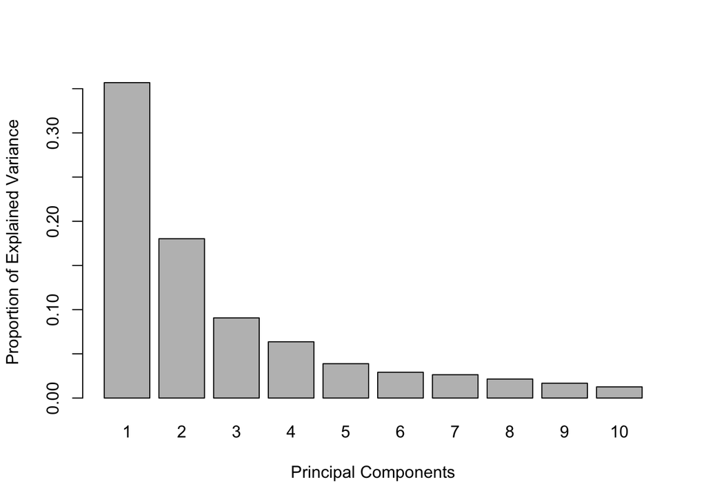

Given the barplot output above, we choose 3principle components for the final analysis.

# PCA

```r
result <- pca(X, ncomp = 3, center = TRUE, scale = FALSE)
result
```

```
## Eigenvalues for the first 3 principal components, see object$sdev^2:
##       PC1       PC2       PC3
## 17.971416  9.079234  4.567709
##
## Proportion of explained variance for the first 3 principal components, see object$explained_variance:
##        PC1        PC2        PC3
## 0.35684128 0.18027769 0.09069665
##
## Cumulative proportion explained variance for the first 3 principal components, see object$cum.var:
##       PC1       PC2       PC3
## 0.3568413 0.5371190 0.6278156
##
##  Other available components:
##  --------------------
##  loading vectors: see object$rotation
```

# Spare Principle Component Analysis (sPCA)

sPCA (see Shen and Huang, 2008) is based on singular value decomposition and is appropriate to deal with large data sets. As implemented in **mixOmics**, ‘Sparsity’ is achieved via LASSO penalizations. sPCA is useful to remove some of the non informative variables in PCA and can be used to investigate whether ‘tighter’ sample clusters can be obtained and which are the variables that highly contribute to the definition of each PC.

For sPCA, the number of variables to select on each PC must be input by the user ( *keepX* ). Tuning sPCA *keepX* is not suitable since bservations and the literature confirm a signifigant drop in the proportion of explained variance. Therefore the amount of explained variance is not a suitable tuning criterion. Since sPCA is an unsupervised and exploratory technique, we prefer to let the user select a ( keepX ) suitable to the research question. The following example show *keepX* which have been choosen arbitrarily to select the first (10, 5, 15) variables that contribute the most to the variance in the data on the PCs 1, 2 and 3. The function **selectVar()** highlights the variables selected on the *comp = 1* PC and outputs their weights in the associated loading vector:

```r
spca.result <- spca(X, ncomp = 3, center = TRUE, scale = TRUE,
                    keepX = c(10, 5, 15))
spca.result
```

```
##
## Call:
##  spca(X = X, ncomp = 3, center = TRUE, scale = TRUE, keepX = c(10, 5, 15))
##
##  sparse pCA with 3 principal components.
##  You entered data X of dimensions: 64 3116
##  Selection of 10 5 15 variables on each of the principal components on the X data set.
##  Main numerical outputs:
##  --------------------
##  loading vectors: see object$rotation
##  principal components: see object$x
##  cumulative explained variance: see object$varX
##  variable names: see object$names
##
##  Other functions:
##  --------------------
##  selectVar, tune
```

```r
selectVar(spca.result, comp = 1)
```

```
## $name
##  [1] "A_43_P16829"  "A_42_P680505" "A_43_P20475"  "A_43_P11409"
##  [5] "A_43_P21269"  "A_42_P814129" "A_43_P20891"  "A_43_P20281"
##  [9] "A_43_P14037"  "A_42_P751969"
##
## $value
##                 value.var
## A_43_P16829  -0.528724414
## A_42_P680505 -0.428398868
## A_43_P20475  -0.411854421
## A_43_P11409  -0.336503346
## A_43_P21269  -0.331792306
## A_42_P814129 -0.245533902
## A_43_P20891  -0.220040298
## A_43_P20281  -0.175262121
## A_43_P14037  -0.067349863
## A_42_P751969 -0.004770662
##
## $comp
## [1] 1
```

See [Case Study: IPCA Multidrug](http://mixomics.org/case-studies/pca-multidrug/) for more examples and plotting options.

# References

## PCA

1. [Jolliffe I.T. (2002) Principle Component Analysis. Springer Series in Statistics, Springer, New York.](http://tocs.ulb.tu-darmstadt.de/182444961.pdf)

## (s)PCA

1. [Shen, H. and Huang, J. Z. (2008). Sparse principle component analysis via regularized low rank matrix approximation. 99(6), 1015–1034.](http://www.sciencedirect.com/science/article/pii/S0047259X07000887)
2. [Witten D.M. and Tibshirani R. and Hastie T. (2009) A penalized matrix decomposition, with applications to sparse principle components and canonical correlation analysis. Biostatistics 10(3)](https://academic.oup.com/biostatistics/article/10/3/515/293026/A-penalized-matrix-decomposition-with-applications)